# IODS course project

### Task4: Standardizing the dataset and print out summaries

```r
# here we are standardizing the data by scaling using the scale() function
boston_scaled <- scale(Boston)

# We shall print the summary of the scaled data by using the function symmary()
summary(boston_scaled)
```

```
##       crim                 zn               indus              chas
##  Min.   :-0.419367   Min.   :-0.48724   Min.   :-1.5563   Min.   :-0.2723
##  1st Qu.:-0.410563   1st Qu.:-0.48724   1st Qu.:-0.8668   1st Qu.:-0.2723
##  Median :-0.390280   Median :-0.48724   Median :-0.2109   Median :-0.2723
##  Mean   : 0.000000   Mean   : 0.00000   Mean   : 0.0000   Mean   : 0.0000
##  3rd Qu.: 0.007389   3rd Qu.: 0.04872   3rd Qu.: 1.0150   3rd Qu.:-0.2723
##  Max.   : 9.924110   Max.   : 3.80047   Max.   : 2.4202   Max.   : 3.6648
##       nox                rm               age               dis
##  Min.   :-1.4644   Min.   :-3.8764   Min.   :-2.3331   Min.   :-1.2658
##  1st Qu.:-0.9121   1st Qu.:-0.5681   1st Qu.:-0.8366   1st Qu.:-0.8049
##  Median :-0.1441   Median :-0.1084   Median : 0.3171   Median :-0.2790
##  Mean   : 0.0000   Mean   : 0.0000   Mean   : 0.0000   Mean   : 0.0000
##  3rd Qu.: 0.5981   3rd Qu.: 0.4823   3rd Qu.: 0.9059   3rd Qu.: 0.6617
##  Max.   : 2.7296   Max.   : 3.5515   Max.   : 1.1164   Max.   : 3.9566
##       rad               tax             ptratio            black
##  Min.   :-0.9819   Min.   :-1.3127   Min.   :-2.7047   Min.   :-3.9033
##  1st Qu.:-0.6373   1st Qu.:-0.7668   1st Qu.:-0.4876   1st Qu.: 0.2049
##  Median :-0.5225   Median :-0.4642   Median : 0.2746   Median : 0.3808
##  Mean   : 0.0000   Mean   : 0.0000   Mean   : 0.0000   Mean   : 0.0000
##  3rd Qu.: 1.6596   3rd Qu.: 1.5294   3rd Qu.: 0.8058   3rd Qu.: 0.4332
##  Max.   : 1.6596   Max.   : 1.7964   Max.   : 1.6372   Max.   : 0.4406
##      lstat              medv
##  Min.   :-1.5296   Min.   :-1.9063
##  1st Qu.:-0.7986   1st Qu.:-0.5989
##  Median :-0.1811   Median :-0.1449
##  Mean   : 0.0000   Mean   : 0.0000
##  3rd Qu.: 0.6024   3rd Qu.: 0.2683
##  Max.   : 3.5453   Max.   : 2.9865
```

The variables of the “scaled data” all have their mean to be zero (0)

```r
# Lets us check whether the scaled data is data frame or not by using is.data.frame() function
is.data.frame(boston_scaled)
```

```
## [1] FALSE
```

Note that the scaled data is not data frame. We will now convert the boston_scale to data frame by usinf the next step.

```r
# Making the boston_scaled data a data frame
boston_scaled <- as.data.frame(boston_scaled)
is.data.frame(boston_scaled)
```

```
## [1] TRUE
```

#### Task 4.2 Create a categorical variable of the crime rate in the Boston dataset

Now the boston_scaled is now a data frame. Hence, we can continue other analysis.

```r
#Let us examine the crime variable of the scaled data
summary(boston_scaled$crim)
```

```
##      Min.   1st Qu.    Median      Mean   3rd Qu.      Max.
## -0.419367 -0.410563 -0.390280  0.000000  0.007389  9.924110
```

```r
# create a quantile vector of crime
q_vector <- quantile(boston_scaled$crim)
# Let us print the quantile vector of crime rate
q_vector
```

```
##           0%          25%          50%          75%         100%
## -0.419366929 -0.410563278 -0.390280295  0.007389247  9.924109610
```

```r
# create a categorical variable 'crime'
crime <- cut(boston_scaled$crim, breaks = q_vector, include.lowest = TRUE, label= c("low", "med_low", "med_high", "high"))
# Let us now use the table() function to see the new factor crime
table(crime)
```

```
## crime
##      low  med_low med_high     high
##      127      126      126      127
```

The crime rate in Boston data now shows on the levels low to high.

#### Task 4.3 Droping the the old crime

```r
# Lests remove original crim from the dataset
boston_scaled <- dplyr::select(boston_scaled, -crim)

# here are would add the new crime to boston_scaled
boston_scaled <- data.frame(boston_scaled, crime)
```

#### Task 4.4 Divide the dataset to train and test sets

```r
 # Let us asign the number of rows in the Boston dataset
n <- nrow(boston_scaled)

# choose randomly 80% of the rows
ind <- sample(n,  size = n * 0.8)
```

Now we will divide divide the dataset to train and test sets

```r
# Lets create train set with 80%
train <- boston_scaled[ind,]

# Lets create test set
test <- boston_scaled[-ind,]
```

### Task 5. Fit the linear discriminant analysis on the train set

```r
# linear discriminant analysis
lda.fit <- lda(crime ~., data = train)

# Lets us print the lda.fit object
lda.fit
```

```
## Call:
## lda(crime ~ ., data = train)
##
## Prior probabilities of groups:
##       low   med_low  med_high      high
## 0.2450495 0.2623762 0.2500000 0.2425743
##
## Group means:
##                  zn      indus         chas        nox          rm        age
## low       0.8757330 -0.9024201 -0.113254311 -0.8701366  0.40833186 -0.8826506
## med_low  -0.0835479 -0.2814484 -0.049474337 -0.5992637 -0.08239068 -0.4218273
## med_high -0.3666748  0.1796885  0.117482837  0.4561655  0.15585191  0.4058814
## high     -0.4872402  1.0149946  0.008892378  1.0641838 -0.40920143  0.7948847
##                 dis        rad        tax     ptratio       black       lstat
## low       0.8879424 -0.6930143 -0.7545308 -0.38724387  0.37924742 -0.75432757
## med_low   0.3771151 -0.5604055 -0.4919211 -0.08752916  0.32147468 -0.20737721
## med_high -0.3749348 -0.3792103 -0.2735216 -0.39700491  0.04168549 -0.07653324
## high     -0.8565339  1.6596029  1.5294129  0.80577843 -0.79138223  0.84851302
##                 medv
## low       0.50208182
## med_low   0.03448843
## med_high  0.22541164
## high     -0.64141199
##
## Coefficients of linear discriminants:
##                 LD1         LD2         LD3
## zn       0.13398721  0.60090882 -0.97295219
## indus   -0.03155310 -0.15061908  0.46113867
## chas    -0.05757449  0.04175281  0.14251583
## nox      0.28227375 -0.94292270 -1.32584542
## rm      -0.10068096 -0.08127416 -0.09651613
## age      0.35416363 -0.34344109 -0.16054311
## dis     -0.09542943 -0.23397106  0.04753130
## rad      3.19617034  0.94080316 -0.16590734
## tax      0.04494788 -0.05358221  0.43511524
## ptratio  0.12948617  0.08751090 -0.28811215
## black   -0.17560701  0.02503827  0.11760480
## lstat    0.13885274 -0.03702518  0.50490618
## medv     0.15532096 -0.31370013 -0.13568314
##
## Proportion of trace:
##    LD1    LD2    LD3
## 0.9494 0.0368 0.0138
```

##### Now let us draw the LDA (bi)plot

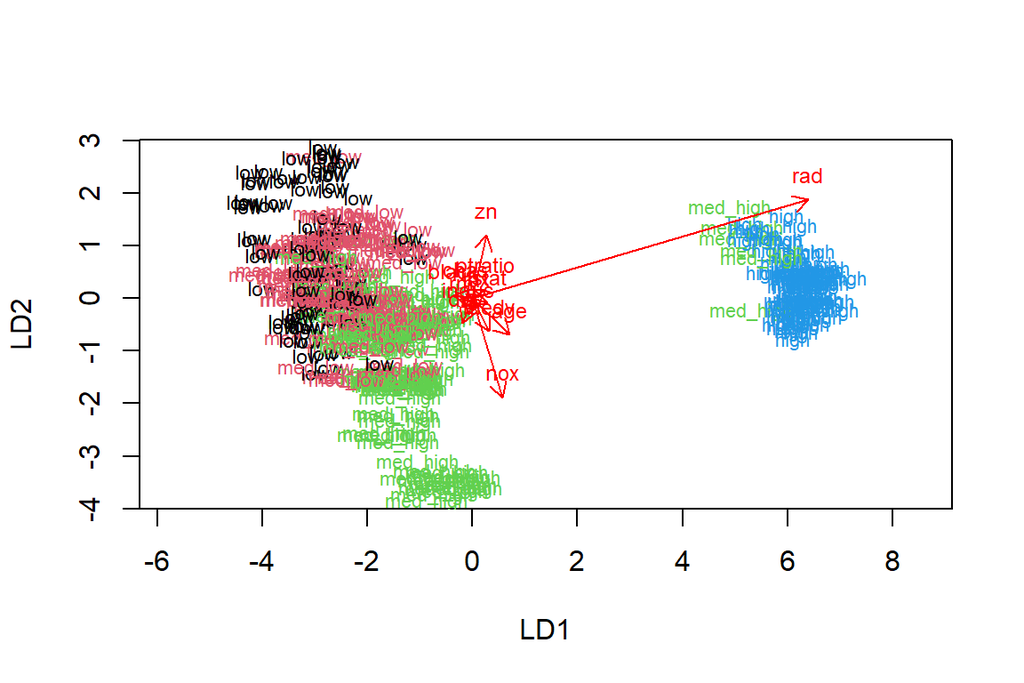

```r
#
# Here is the function for lda biplot arrows copied from Datacamp
lda.arrows <- function(x, myscale = 1, arrow_heads = 0.1, color = "red", tex = 0.75, choices = c(1,2)){
  heads <- coef(x)
  arrows(x0 = 0, y0 = 0,
         x1 = myscale * heads[,choices[1]],
         y1 = myscale * heads[,choices[2]], col=color, length = arrow_heads)
  text(myscale * heads[,choices], labels = row.names(heads),
       cex = tex, col=color, pos=3)
}


# target classes as numeric
classes <- as.numeric(train$crime)

# plot the lda results
plot(lda.fit, dimen = 2, col = classes, pch = classes)
lda.arrows(lda.fit, myscale = 2)
```

In this graph, it shows that “rad” variable is the most influential among other variables, hence the long arrow is pointing to it. Variable rad is a cluster of high (blue color) and med_high (green color)

### Task 6

```r
# save the correct classes from test data
correct_classes <- test$crime

# predicting classes with test data
lda.pred <- predict(lda.fit, newdata = test)

# cross tabulating the results
table(correct = correct_classes, predicted = lda.pred$class)
```

```
##           predicted
## correct    low med_low med_high high
##   low       17      11        0    0
##   med_low    1      13        6    0
##   med_high   0      13       12    0
##   high       0       0        1   28
```

### Task 7.

I am going to load the Boston dataset again by using the following lines of codes

```r
# Calling the library MASS
library(MASS)

#loading the data
data("Boston")

#scaling BIstin data set

boston_scaled_2 <- scale(Boston)
is.data.frame(boston_scaled_2)  #checking whether the boston_scalled2 is a data frame
```

```
## [1] FALSE
```

```r
boston_scaled_2 <- as.data.frame(boston_scaled_2)   # converting the boston_scalled_2 to data frame
is.data.frame(boston_scaled_2)
```

```
## [1] TRUE
```

Here we shall now Calculate the euclidean distances between the observations. The distance matrix is usually square matrix containing the pairwise distances of the observations.

```r
# calculating the euclidean distance matrix
dist_eu <- dist(boston_scaled_2)

# We nlw look at the summary of the distances
summary(dist_eu)
```

```
##    Min. 1st Qu.  Median    Mean 3rd Qu.    Max.
##  0.1343  3.4625  4.8241  4.9111  6.1863 14.3970
```

Here we will run k-means algorithm on the boston_scaled_2 data set with this codes below

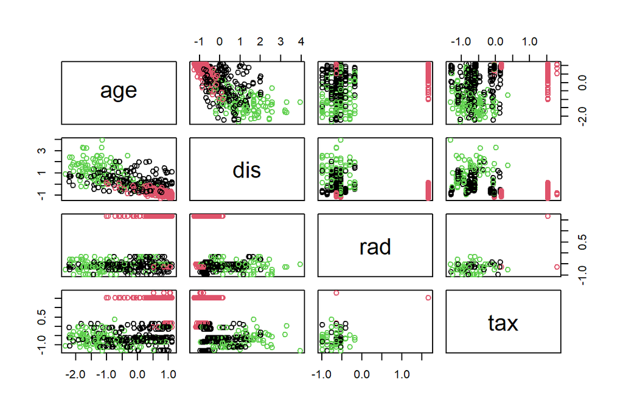

```r
# k-means clustering
km <-kmeans(boston_scaled_2, centers = 3)

#pairs(boston_scaled_2)

# plot the Boston dataset with clusters
pairs(boston_scaled_2[7:10], col = km$cluster)
```

After setting the kmeans cluster to 1,2,3,4,5 and 6, I think the optimal number of cluster is 3. From the diagram above, the k-mean cluster is 3 and the numbers of pairs() plot is reduced to 4 so that the visualization can be seen clearly.

It can be seen that there are 3 clusters in the plot separated with colors green, red, and black. The green cluster dominates, followed by the black cluster, and finally the red cluster.

*PLEASE NOTE THAT I OBSERVED THAT EVERYTIME YOU KNIT, THE CLUSTERING CHANGES SLIGHTLY IN TERMS OF COLORS AND CONCENTRATION7GROUPING*

# Dimensionality reduction techniques (Chapter 5)

*In this section, we will describe the steps taken to perform the dimensionality reduction techniques with “human” data obtained and wranged.*

```r
#install.packages("GGally")
library(dplyr)
library(ggplot2)
library(GGally)
# Let us begin by reading the "human data from local storage
human <-  read.table("http://s3.amazonaws.com/assets.datacamp.com/production/course_2218/datasets/human2.txt", sep = "," , header=TRUE)
#human <- read.csv("C:\\Users\\fridaya\\Documents\\IODS-project\\data\\human.csv")
```

*NOTE: After I completed the data wrangling the last erxercise of replacing the rownames with country did not work well. Hence, I would not continue to use that file but loaded the data from the link provided in the line 13. That altered my naming conventions* #############################

### Let us take a look at the structure and dimention of the human data

```r
str(human) # Exploring the structure of the human data
```

```
## 'data.frame':    155 obs. of  8 variables:
##  $ Edu2.FM  : num  1.007 0.997 0.983 0.989 0.969 ...
##  $ Labo.FM  : num  0.891 0.819 0.825 0.884 0.829 ...
##  $ Edu.Exp  : num  17.5 20.2 15.8 18.7 17.9 16.5 18.6 16.5 15.9 19.2 ...
##  $ Life.Exp : num  81.6 82.4 83 80.2 81.6 80.9 80.9 79.1 82 81.8 ...
##  $ GNI      : int  64992 42261 56431 44025 45435 43919 39568 52947 42155 32689 ...
##  $ Mat.Mor  : int  4 6 6 5 6 7 9 28 11 8 ...
##  $ Ado.Birth: num  7.8 12.1 1.9 5.1 6.2 3.8 8.2 31 14.5 25.3 ...
##  $ Parli.F  : num  39.6 30.5 28.5 38 36.9 36.9 19.9 19.4 28.2 31.4 ...
```

```r
dim(human) # exploring the dimensions of the human data
```

```
## [1] 155   8
```

### Let us look at the summary of the data

```r
# Summary of the human data
summary(human)
```

```
##     Edu2.FM          Labo.FM          Edu.Exp         Life.Exp
##  Min.   :0.1717   Min.   :0.1857   Min.   : 5.40   Min.   :49.00
##  1st Qu.:0.7264   1st Qu.:0.5984   1st Qu.:11.25   1st Qu.:66.30
##  Median :0.9375   Median :0.7535   Median :13.50   Median :74.20
##  Mean   :0.8529   Mean   :0.7074   Mean   :13.18   Mean   :71.65
##  3rd Qu.:0.9968   3rd Qu.:0.8535   3rd Qu.:15.20   3rd Qu.:77.25
##  Max.   :1.4967   Max.   :1.0380   Max.   :20.20   Max.   :83.50
##       GNI            Mat.Mor         Ado.Birth         Parli.F
##  Min.   :   581   Min.   :   1.0   Min.   :  0.60   Min.   : 0.00
##  1st Qu.:  4198   1st Qu.:  11.5   1st Qu.: 12.65   1st Qu.:12.40
##  Median : 12040   Median :  49.0   Median : 33.60   Median :19.30
##  Mean   : 17628   Mean   : 149.1   Mean   : 47.16   Mean   :20.91
##  3rd Qu.: 24512   3rd Qu.: 190.0   3rd Qu.: 71.95   3rd Qu.:27.95
##  Max.   :123124   Max.   :1100.0   Max.   :204.80   Max.   :57.50
```

### Now, we would show the graphical overview of the data

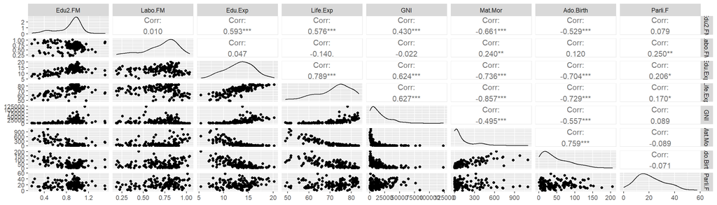

Figure 1. Visualization of the variables of the human data

### Task 2. Performing principal component analysis (PCA) on the not standardized human data

```r
# performing PCA  analysis on the unstandardized data
pca_human <- prcomp(human)

# Show the variability captured by the PCA
summary(pca_human)
```

```
## Importance of components:
##                              PC1      PC2   PC3   PC4   PC5   PC6    PC7    PC8
## Standard deviation     1.854e+04 185.5219 25.19 11.45 3.766 1.566 0.1912 0.1591
## Proportion of Variance 9.999e-01   0.0001  0.00  0.00 0.000 0.000 0.0000 0.0000
## Cumulative Proportion  9.999e-01   1.0000  1.00  1.00 1.000 1.000 1.0000 1.0000
```

```r
pca_human
```

```
## Standard deviations (1, .., p=8):
## [1] 1.854416e+04 1.855219e+02 2.518701e+01 1.145441e+01 3.766241e+00
## [6] 1.565912e+00 1.912052e-01 1.591112e-01
##
## Rotation (n x k) = (8 x 8):
##                     PC1           PC2           PC3           PC4           PC5
## Edu2.FM   -5.607472e-06  0.0006713951 -3.412027e-05 -2.736326e-04 -0.0022935252
## Labo.FM    2.331945e-07 -0.0002819357  5.302884e-04 -4.692578e-03  0.0022190154
## Edu.Exp   -9.562910e-05  0.0075529759  1.427664e-02 -3.313505e-02  0.1431180282
## Life.Exp  -2.815823e-04  0.0283150248  1.294971e-02 -6.752684e-02  0.9865644425
## GNI       -9.999832e-01 -0.0057723054 -5.156742e-04  4.932889e-05 -0.0001135863
## Mat.Mor    5.655734e-03 -0.9916320120  1.260302e-01 -6.100534e-03  0.0266373214
## Ado.Birth  1.233961e-03 -0.1255502723 -9.918113e-01  5.301595e-03  0.0188618600
## Parli.F   -5.526460e-05  0.0032317269 -7.398331e-03 -9.971232e-01 -0.0716401914
##                     PC6           PC7           PC8
## Edu2.FM    2.180183e-02  6.998623e-01  7.139410e-01
## Labo.FM    3.264423e-02  7.132267e-01 -7.001533e-01
## Edu.Exp    9.882477e-01 -3.826887e-02  7.776451e-03
## Life.Exp  -1.453515e-01  5.380452e-03  2.281723e-03
## GNI       -2.711698e-05 -8.075191e-07 -1.176762e-06
## Mat.Mor    1.695203e-03  1.355518e-04  8.371934e-04
## Ado.Birth  1.273198e-02 -8.641234e-05 -1.707885e-04
## Parli.F   -2.309896e-02 -2.642548e-03  2.680113e-03
```

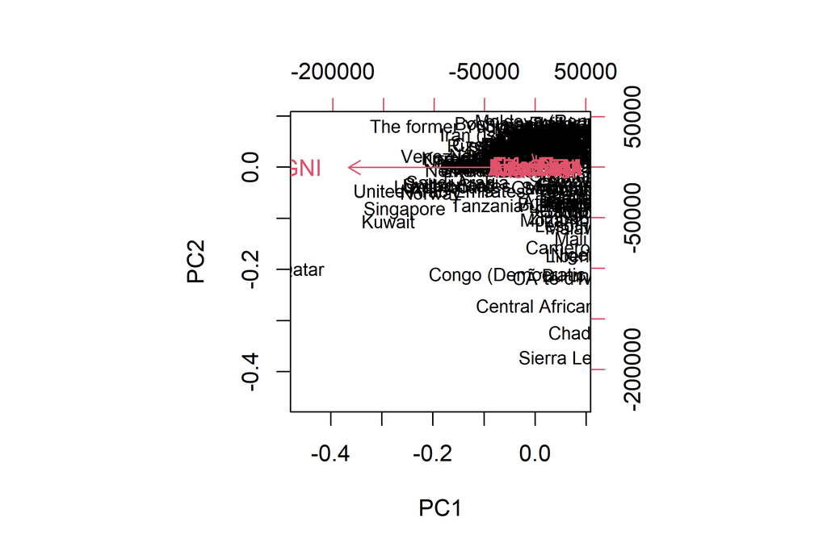

```r
# Let us plot the biplot displaying the observations by the first two principal components
biplot(pca_human, choices = 1:2, cex = c(0.8, 1))
```

```r
#biplot(pca_human, choices = 1:2)
```

Figure 2. PCA plot of unstandardised data

### Task 3. Performing principal component analysis (PCA) on the standardized human data

[output not shown]

[output not shown]

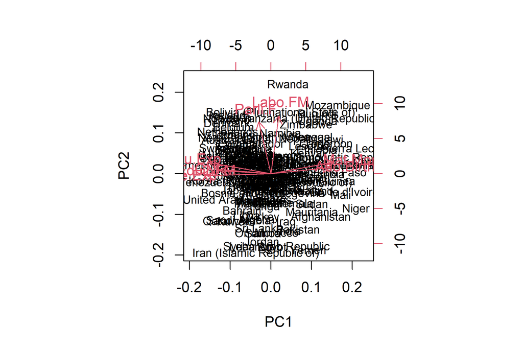

```r
# Let us plot the biplot displaying the observations by the first two principal components
biplot(pca_human, choices = 1:2, cex = c(0.8, 1))
```

Figure 2. PCA plot of standardised data

#### Explanation of the two visualization

We observe that the two results of PCA in the plots are significantly different. The unstandardized PCA was clustered to the top right of the graph and most of the observations (records) were not visible to interprete. However, the PCA result of the standardized data revealed almost all the observations, which makes it easier to see the differences and correlations between them. Therefore, it is recommended to standardize data before analysing the PCA in order to gain more insight into the results.

### Task 4

To interpret the results, the biplot displays the multiple correlation between the original features and the PC. The arrows pointing to the same direction as the PC axis represent the features contributing to that PC.The angle between the original features and the PC provides critical information. The smaller the angle, the more correlated the features. Lastly the lenght of the arrow indicate their standard deviations.

In the PC plot above, it was observed that Parli.f and Labo.FM are more correlated compared to Edu.Exp and Labo.FM

```r
#library(corrplot)
#library(FactoMineR)
#data(tea)

#str(tea)
#dim(tea)

#keep_columns <- c("Tea", "How", "how", "sophisticated", "where", "spirituality")

#tea_time <- select(tea, one_of(keep_columns))
#mca <- MCA(tea_time, graph = FALSE)

#plot(mca, invisible=c("ind"), habillage = "quali", graph.type = "classic")
```

# Analysis of longitudinal data (Chapter 6)

*We begin in this chapter by reading the BPRS and RATS wide form and the converted BPRSLONG and RATSLONG long form already completed and saved during the data wrangling exercise in “meet_and_repeat” R script.*

```r
library(dplyr)
library(ggplot2)
library(GGally)
library(tidyr)
```

### Summary of BPRS Data

```r
# Let us read the BPRS data and take a look at the data summary
BPRS  <- read.table("https://raw.githubusercontent.com/KimmoVehkalahti/MABS/master/Examples/data/BPRS.txt", sep=" ", header=TRUE) # BPRS Wide form

# Let us check the BPRS data names, structures, and summary

names(BPRS) # ... checking the column names
```

```
##  [1] "treatment" "subject"   "week0"     "week1"     "week2"     "week3"
##  [7] "week4"     "week5"     "week6"     "week7"     "week8"
```

```r
str(BPRS) # ... checking the structure of the BPRS
```

```
## 'data.frame':    40 obs. of  11 variables:
##  $ treatment: int  1 1 1 1 1 1 1 1 1 1 ...
##  $ subject  : int  1 2 3 4 5 6 7 8 9 10 ...
##  $ week0    : int  42 58 54 55 72 48 71 30 41 57 ...
##  $ week1    : int  36 68 55 77 75 43 61 36 43 51 ...
##  $ week2    : int  36 61 41 49 72 41 47 38 39 51 ...
##  $ week3    : int  43 55 38 54 65 38 30 38 35 55 ...
##  $ week4    : int  41 43 43 56 50 36 27 31 28 53 ...
##  $ week5    : int  40 34 28 50 39 29 40 26 22 43 ...
##  $ week6    : int  38 28 29 47 32 33 30 26 20 43 ...
##  $ week7    : int  47 28 25 42 38 27 31 25 23 39 ...
##  $ week8    : int  51 28 24 46 32 25 31 24 21 32 ...
```

```r
summary(BPRS) # .... checking the summary of the BPRS data
```

```
##    treatment      subject          week0           week1           week2
##  Min.   :1.0   Min.   : 1.00   Min.   :24.00   Min.   :23.00   Min.   :26.0
##  1st Qu.:1.0   1st Qu.: 5.75   1st Qu.:38.00   1st Qu.:35.00   1st Qu.:32.0
##  Median :1.5   Median :10.50   Median :46.00   Median :41.00   Median :38.0
##  Mean   :1.5   Mean   :10.50   Mean   :48.00   Mean   :46.33   Mean   :41.7
##  3rd Qu.:2.0   3rd Qu.:15.25   3rd Qu.:58.25   3rd Qu.:54.25   3rd Qu.:49.0
##  Max.   :2.0   Max.   :20.00   Max.   :78.00   Max.   :95.00   Max.   :75.0
##      week3           week4           week5           week6           week7
##  Min.   :24.00   Min.   :20.00   Min.   :20.00   Min.   :19.00   Min.   :18.0
##  1st Qu.:29.75   1st Qu.:28.00   1st Qu.:26.00   1st Qu.:22.75   1st Qu.:23.0
##  Median :36.50   Median :34.50   Median :30.50   Median :28.50   Median :30.0
##  Mean   :39.15   Mean   :36.35   Mean   :32.55   Mean   :31.23   Mean   :32.2
##  3rd Qu.:44.50   3rd Qu.:43.00   3rd Qu.:38.00   3rd Qu.:37.00   3rd Qu.:38.0
##  Max.   :76.00   Max.   :66.00   Max.   :64.00   Max.   :64.00   Max.   :62.0
##      week8
##  Min.   :20.00
##  1st Qu.:22.75
##  Median :28.00
##  Mean   :31.43
##  3rd Qu.:35.25
##  Max.   :75.00
```

```r
#BPRS
```

The brief psychiatric rating scale (BPRS) is used to evaluate whether or not the patient has schizophrenia. The data contain 40 observations and 11 variables.

```r
# Next, we load the long form of the BPRS saved in the local computer
BPRSLONG <- read.csv("C:\\Users\\fridaya\\Documents\\IODS-project\\data\\BPRSLONG.csv")

# Let us check the BPRSLONG data names, structures, and summary

names(BPRSLONG) # ... checking the column names
```

```
## [1] "treatment" "subject"   "weeks"     "bprs"      "week"
```

```r
str(BPRSLONG) # ... checking the structure of the BPRSLONG data
```

```
## 'data.frame':    360 obs. of  5 variables:
##  $ treatment: int  1 1 1 1 1 1 1 1 1 1 ...
##  $ subject  : int  1 2 3 4 5 6 7 8 9 10 ...
##  $ weeks    : chr  "week0" "week0" "week0" "week0" ...
##  $ bprs     : int  42 58 54 55 72 48 71 30 41 57 ...
##  $ week     : int  0 0 0 0 0 0 0 0 0 0 ...
```

```r
summary(BPRSLONG) # .... checking the summary of the BPRSLONG data
```

```
##    treatment      subject         weeks                bprs            week
##  Min.   :1.0   Min.   : 1.00   Length:360         Min.   :18.00   Min.   :0
##  1st Qu.:1.0   1st Qu.: 5.75   Class :character   1st Qu.:27.00   1st Qu.:2
##  Median :1.5   Median :10.50   Mode  :character   Median :35.00   Median :4
##  Mean   :1.5   Mean   :10.50                      Mean   :37.66   Mean   :4
##  3rd Qu.:2.0   3rd Qu.:15.25                      3rd Qu.:43.00   3rd Qu.:6
##  Max.   :2.0   Max.   :20.00                      Max.   :95.00   Max.   :8
```

We observed that the Long form of the data contained 360 observations and 5 variables.

### Summary of RATS data

```r
# Let us read the RATS data and take a look at the data summary
RATS  <- read.table("https://raw.githubusercontent.com/KimmoVehkalahti/MABS/master/Examples/data/rats.txt", sep="\t", header=TRUE) # RATS Wide form

# Let us check the RATS data names, structures, and summary

names(RATS) # ... checking the column names
```

```
##  [1] "ID"    "Group" "WD1"   "WD8"   "WD15"  "WD22"  "WD29"  "WD36"  "WD43"
## [10] "WD44"  "WD50"  "WD57"  "WD64"
```

```r
str(RATS) # ... checking the structure of the RATS
```

```
## 'data.frame':    16 obs. of  13 variables:
##  $ ID   : int  1 2 3 4 5 6 7 8 9 10 ...
##  $ Group: int  1 1 1 1 1 1 1 1 2 2 ...
##  $ WD1  : int  240 225 245 260 255 260 275 245 410 405 ...
##  $ WD8  : int  250 230 250 255 260 265 275 255 415 420 ...
##  $ WD15 : int  255 230 250 255 255 270 260 260 425 430 ...
##  $ WD22 : int  260 232 255 265 270 275 270 268 428 440 ...
##  $ WD29 : int  262 240 262 265 270 275 273 270 438 448 ...
##  $ WD36 : int  258 240 265 268 273 277 274 265 443 460 ...
##  $ WD43 : int  266 243 267 270 274 278 276 265 442 458 ...
##  $ WD44 : int  266 244 267 272 273 278 271 267 446 464 ...
##  $ WD50 : int  265 238 264 274 276 284 282 273 456 475 ...
##  $ WD57 : int  272 247 268 273 278 279 281 274 468 484 ...
##  $ WD64 : int  278 245 269 275 280 281 284 278 478 496 ...
```

```r
summary(RATS) # .... checking the summary of the RATS data
```

```
##        ID            Group           WD1             WD8             WD15
##  Min.   : 1.00   Min.   :1.00   Min.   :225.0   Min.   :230.0   Min.   :230.0
##  1st Qu.: 4.75   1st Qu.:1.00   1st Qu.:252.5   1st Qu.:255.0   1st Qu.:255.0
##  Median : 8.50   Median :1.50   Median :340.0   Median :345.0   Median :347.5
##  Mean   : 8.50   Mean   :1.75   Mean   :365.9   Mean   :369.1   Mean   :372.5
##  3rd Qu.:12.25   3rd Qu.:2.25   3rd Qu.:480.0   3rd Qu.:476.2   3rd Qu.:486.2
##  Max.   :16.00   Max.   :3.00   Max.   :555.0   Max.   :560.0   Max.   :565.0
##       WD22            WD29            WD36            WD43
##  Min.   :232.0   Min.   :240.0   Min.   :240.0   Min.   :243.0
##  1st Qu.:267.2   1st Qu.:268.8   1st Qu.:267.2   1st Qu.:269.2
##  Median :351.5   Median :356.5   Median :360.0   Median :360.0
##  Mean   :379.2   Mean   :383.9   Mean   :387.0   Mean   :386.0
##  3rd Qu.:492.5   3rd Qu.:497.8   3rd Qu.:504.2   3rd Qu.:501.0
##  Max.   :580.0   Max.   :590.0   Max.   :597.0   Max.   :595.0
##       WD44            WD50            WD57            WD64
##  Min.   :244.0   Min.   :238.0   Min.   :247.0   Min.   :245.0
##  1st Qu.:270.0   1st Qu.:273.8   1st Qu.:273.8   1st Qu.:278.0
##  Median :362.0   Median :370.0   Median :373.5   Median :378.0
##  Mean   :388.3   Mean   :394.6   Mean   :398.6   Mean   :404.1
##  3rd Qu.:510.5   3rd Qu.:516.0   3rd Qu.:524.5   3rd Qu.:530.8
##  Max.   :595.0   Max.   :612.0   Max.   :618.0   Max.   :628.0
```

```r
#BPRS
```

The RATS data and their nutrition in its wide form contain 16 observations and 13 variables

```r
# Next, we load the long form of the RATS data saved in the local computer
RATSLONG <- read.csv("C:\\Users\\fridaya\\Documents\\IODS-project\\data\\RATSLONG.csv")

# Let us check the RATSLONG data names, structures, and summary

names(RATSLONG) # ... checking the column names
```

```
## [1] "ID"     "Group"  "WD"     "Weight" "Time"
```

```r
str(RATSLONG) # ... checking the structure of the RATSLONG
```

```
## 'data.frame':    176 obs. of  5 variables:
##  $ ID    : int  1 2 3 4 5 6 7 8 9 10 ...
##  $ Group : int  1 1 1 1 1 1 1 1 2 2 ...
##  $ WD    : chr  "WD1" "WD1" "WD1" "WD1" ...
##  $ Weight: int  240 225 245 260 255 260 275 245 410 405 ...
##  $ Time  : int  1 1 1 1 1 1 1 1 1 1 ...
```

```r
summary(RATSLONG) # .... checking the summary of the RATSLONG data
```

```
##        ID            Group           WD                Weight
##  Min.   : 1.00   Min.   :1.00   Length:176         Min.   :225.0
##  1st Qu.: 4.75   1st Qu.:1.00   Class :character   1st Qu.:267.0
##  Median : 8.50   Median :1.50   Mode  :character   Median :344.5
##  Mean   : 8.50   Mean   :1.75                      Mean   :384.5
##  3rd Qu.:12.25   3rd Qu.:2.25                      3rd Qu.:511.2
##  Max.   :16.00   Max.   :3.00                      Max.   :628.0
##       Time
##  Min.   : 1.00
##  1st Qu.:15.00
##  Median :36.00
##  Mean   :33.55
##  3rd Qu.:50.00
##  Max.   :64.00
```

After converting the RATS data to its long form, we then have 176 observations and 5 variables.